# zoo FAQ

## 1. I know that duplicate times are not allowed but my data has them. What do I do?

`zoo` objects should not normally contain duplicate times. If you try to create such an object using `zoo` or `read.zoo` then warnings will be issued but the objects will be created. The user then has the opportunity to fix them up – typically by using `aggregate.zoo` or `duplicated`.

Merging is not well defined for duplicate series with duplicate times and rather than give an undesired or unexpected result, `merge.zoo` issues an error message if it encounters such illegal objects. Since `merge.zoo` is the workhorse behind many `zoo` functions, a significant portion of `zoo` will not accept duplicates among the times.

Typically duplicates are eliminated by (1) averaging over them, (2) taking the last among each run of duplicates or (3) interpolating the duplicates and deleting ones on the end that cannot be interpolated. These three approaches are shown here using the `aggregate.zoo` function. Another way to do this is to use the `aggregate` argument of `read.zoo` which will aggregate the zoo object read in by `read.zoo` all in one step.

Note that in the example code below that `identity` is the identity function (i.e. it just returns its argument). It is an R core function:

A `"zoo"` series with duplicated indexes

```r
z <- suppressWarnings(zoo(1:8, c(1, 2, 2, 2, 3, 4, 5, 5)))
z
```

```
## 1 2 2 2 3 4 5 5
## 1 2 3 4 5 6 7 8
```

Fix it up by averaging duplicates:

```r
aggregate(z, identity, mean)
```

```
##   1   2   3   4   5
## 1.0 3.0 5.0 6.0 7.5
```

Or, fix it up by taking last in each set of duplicates:

```r
aggregate(z, identity, tail, 1)
```

```
## 1 2 3 4 5
## 1 4 5 6 8
```

Fix it up via interpolation of duplicate times

```r
time(z) <- na.approx(ifelse(duplicated(time(z)), NA, time(z)), na.rm = FALSE)
```

If there is a run of equal times at end they wind up as `NA`s and we cannot have `NA` times.

```r
z[!is.na(time(z))]
```

```
##      1      2 2.3333 2.6667      3      4      5
##      1      2      3      4      5      6      7
```

The `read.zoo` command has an `aggregate` argument that supports arbitrary summarization. For example, in the following we take the last value among any duplicate times and sum the volumes among all duplicate times. We do this by reading the data twice, once for each aggregate function. In this example, the first three columns are junk that we wish to suppress which is why we specified `colClasses`; however, in most cases that argument would not be necessary.

```r
Lines <- "1|BHARTIARTL|EQ|18:15:05|600|1
2|BHARTIARTL|EQ|18:15:05|600|99
3|GLENMARK|EQ|18:15:05|238.1|5
4|HINDALCO|EQ|18:15:05|43.75|100
5|BHARTIARTL|EQ|18:15:05|600|1
6|BHEL|EQ|18:15:05|1100|11
7|HINDALCO|EQ|18:15:06|43.2|1
8|CHAMBLFERT|EQ|18:15:06|46|10
9|CHAMBLFERT|EQ|18:15:06|46|90
10|BAJAUTOFIN|EQ|18:15:06|80|100"

library("zoo")
library("chron")

tail1 <- function(x) tail(x, 1)
cls <- c("NULL", "NULL", "NULL", "character", "numeric", "numeric")
nms <- c("", "", "", "time", "value", "volume")

z <- read.zoo(text = Lines, aggregate = tail1,
  FUN = times, sep = "|", colClasses = cls, col.names = nms)

z2 <- read.zoo(text = Lines, aggregate = sum,
  FUN = times, sep = "|", colClasses = cls, col.names = nms)

z$volume <- z2$volume
z
```

```
##          value volume
## 18:15:05  1100    217
## 18:15:06    80    201
```

If the reason for the duplicate times is that the data is stored in long format then use `read.zoo` (particlarly the `split` argument) to convert it to wide format. Wide format is typically a time series whereas long format is not so wide format is the suitable one for zoo.

```r
Lines <- "Date Stock Price
2000-01-01 IBM 10
2000-01-02 IBM 11
2000-01-01 ORCL 12
2000-01-02 ORCL 13"

stocks <- read.zoo(text = Lines, header = TRUE, split = "Stock")
stocks
```

```
##            IBM ORCL
## 2000-01-01  10   12
## 2000-01-02  11   13
```

## 2. When I try to specify a log axis to `plot.zoo` a warning is issued. What is wrong?

Arguments that are part of `...` are passed to the `panel` function and the default `panel` function, `lines`, does not accept `log`.  
Either ignore the warning, use `suppressWarnings` (see `?suppressWarnings`) or create your own panel function which excludes the `log`:

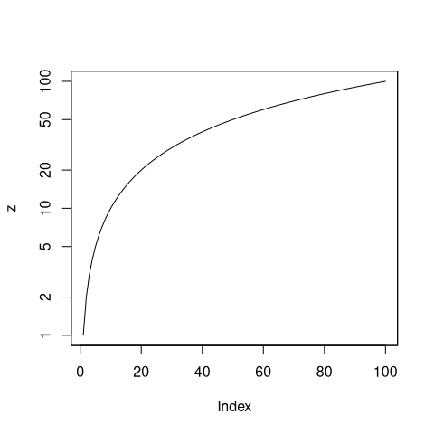

```r
z <- zoo(1:100)
plot(z, log = "y", panel = function(..., log) lines(...))
```

## 3. How do I create right and a left vertical axes in `plot.zoo`?

The following shows an example of creating a plot containing a single panel and both left and right axes.

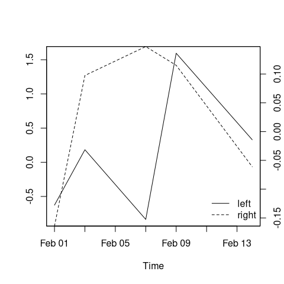

```r
set.seed(1)
z.Date <- as.Date(paste(2003, 02, c(1, 3, 7, 9, 14), sep = "-"))
z <- zoo(cbind(left = rnorm(5), right = rnorm(5, sd = 0.2)), z.Date)

plot(z[,1], xlab = "Time", ylab = "")
opar <- par(usr = c(par("usr")[1:2], range(z[,2])))
lines(z[,2], lty = 2)

axis(side = 4)
legend("bottomright", lty = 1:2, legend = colnames(z), bty="n")
```

```r
par(opar)
```

## 4. I have data frame with both numeric and factor columns. How do I convert that to a `"zoo"` object?

A `"zoo"` object may be (1) a numeric vector, (2) a numeric matrix or (3) a factor but may not contain both a numeric vector and factor.  
The underlying reason for this constraint is that `"zoo"` was intended to generalize R’s `"ts"` class, which is also based on matrices, to irregularly spaced series with an arbitrary index class. The main reason to stick to matrices is that operations on matrices in R are much faster than on data frames.

If you have a data frame with both numeric and factor variables that you want to convert to `"zoo"`, you can do one of the following.

Use two `"zoo"` variables instead:

```r
DF <- data.frame(time = 1:4, x = 1:4, f = factor(letters[c(1, 1, 2, 2)]))
zx <- zoo(DF$x, DF$time)
zf <- zoo(DF$f, DF$time)
```

These could also be held in a `"data.frame"` again:

```r
DF2 <- data.frame(x = zx, f = zf)
```

Or convert the factor to numeric and create a single `"zoo"` series:

```r
z <- zoo(data.matrix(DF[-1]), DF$time)
```

## 5. Why does lag give slightly different results on a `"zoo"` and a `"zooreg"` series which are otherwise the same?

To be definite let us consider the following examples, noting how both `lag` and `diff` give a different answer with the same input except its class is `"zoo"` in one case and `"zooreg"` in another:

```r
z <- zoo(11:15, as.Date("2008-01-01") + c(-4, 1, 2, 3, 6))
zr <- as.zooreg(z)

lag(z)
```

```
## 2007-12-28 2008-01-02 2008-01-03 2008-01-04
##         12         13         14         15
```

```r
lag(zr)
```

```
## 2007-12-27 2008-01-01 2008-01-02 2008-01-03 2008-01-06
##         11         12         13         14         15
```

```r
diff(log(z))
```

```
## 2008-01-02 2008-01-03 2008-01-04 2008-01-07
## 0.08701138 0.08004271 0.07410797 0.06899287
```

```r
diff(log(zr))
```

```
## 2008-01-03 2008-01-04
## 0.08004271 0.07410797
```

`lag.zoo` and `lag.zooreg` work differently. For `"zoo"` objects the lagged version is obtained by moving values to the adjacent time point that exists in the series but for `"zooreg"` objects the time is lagged by `deltat`, the time between adjacent regular times.

A key implication is that `"zooreg"` can lag a point to a time point that did not previously exist in the series and, in particular, can lag a series outside of the original time range whereas that is not possible in a `"zoo"` series.

Note that `lag.zoo` has an `na.pad=` argument which in some cases may be what is being sought here.

The difference between `diff.zoo` and `diff.zooreg` stems from the fact that `diff(x)` is defined in terms of `lag` like this: `x-lag(x,-1)`.

## 6. How do I subtract the mean of each month from a `"zoo"` series?

Suppose we have a daily series. To subtract the mean of Jan 2007 from each day in that month, subtract the mean of Feb 2007 from each day in that month, etc. try this:

```r
set.seed(123)
z <- zoo(rnorm(100), as.Date("2007-01-01") + seq(0, by = 10, length = 100))
z.demean1 <- z - ave(z, as.yearmon(time(z)))
```

This first generates some artificial data and then employs `ave` to compute monthly means.

To subtract the mean of all Januaries from each January, etc. try this:

```r
z.demean2 <- z - ave(z, format(time(z), "%m"))
```

## 7. How do I create a monthly series but still keep track of the dates?

Create a S3 subclass of `"yearmon"` called `"yearmon2"` that stores the dates as names on the time vector. It will be sufficient to create an `as.yearmon2` generic together with an `as.yearmon2.Date` methods as well as the inverse: `as.Date.yearmon2`.

```r
as.yearmon2 <- function(x, ...) UseMethod("as.yearmon2")
as.yearmon2.Date <- function(x, ...) {
  y <- as.yearmon(with(as.POSIXlt(x, tz = "GMT"), 1900 + year + mon/12))
  names(y) <- x
  structure(y, class = c("yearmon2", class(y)))
}
```

`as.Date.yearmon2` is inverse of `as.yearmon2.Date`

```r
as.Date.yearmon2 <- function(x, frac = 0, ...) {
  if (!is.null(names(x))) return(as.Date(names(x)))
  x <- unclass(x)
  year <- floor(x + .001)
  month <- floor(12 * (x - year) + 1 + .5 + .001)
  dd.start <- as.Date(paste(year, month, 1, sep = "-"))
  dd.end <- dd.start + 32 - as.numeric(format(dd.start + 32, "%d"))
  as.Date((1-frac) * as.numeric(dd.start) + frac * as.numeric(dd.end),
    origin = "1970-01-01")
}
```

This new class will act the same as `"yearmon"` stores and allows recovery of the dates using `as.Date` and `aggregate.zoo`.

```r
dd <- seq(as.Date("2000-01-01"), length = 5, by = 32)
z <- zoo(1:5, as.yearmon2(dd))
z
```

```
## Jan 2000 Feb 2000 Mar 2000 Apr 2000 May 2000
##        1        2        3        4        5
```

```r
aggregate(z, as.Date, identity)
```

```
## 2000-01-01 2000-02-02 2000-03-05 2000-04-06 2000-05-08
##          1          2          3          4          5
```

## 8. How are axes added to a plot created using `plot.zoo`?

On single panel plots `axis` or `Axis` can be used just as with any classic graphics plot in R.

The following example adds custom axis for single panel plot. It labels months but uses the larger year for January. Months, quarters and years should have successively larger ticks.

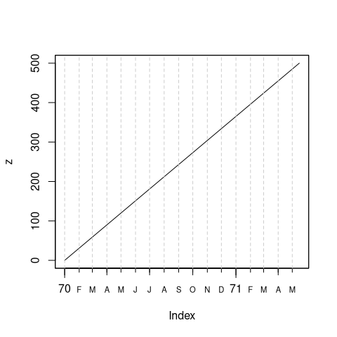

```r
z <- zoo(0:500, as.Date(0:500))
plot(z, xaxt = "n")
tt <- time(z)
m <- unique(as.Date(as.yearmon(tt)))
jan <- format(m, "%m") == "01"
mlab <- substr(months(m[!jan]), 1, 1)
axis(side = 1, at = m[!jan], labels = mlab, tcl = -0.3, cex.axis = 0.7)
axis(side = 1, at = m[jan], labels = format(m[jan], "%y"), tcl = -0.7)
axis(side = 1, at = unique(as.Date(as.yearqtr(tt))), labels = FALSE)

abline(v = m, col = grey(0.8), lty = 2)
```

A multivariate series can either be generated as (1) multiple single panel plots:

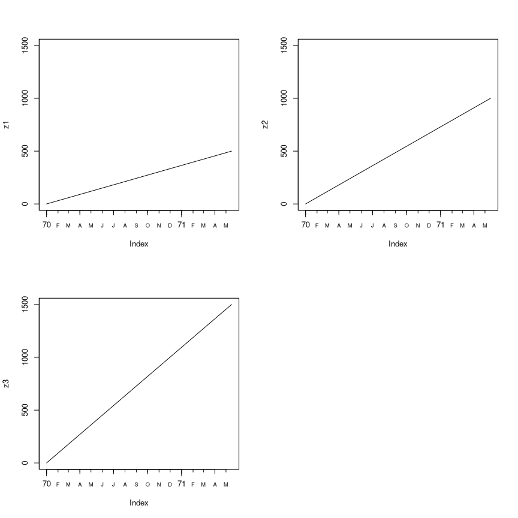

```r
z3 <- cbind(z1 = z, z2 = 2*z, z3 = 3*z)
opar <- par(mfrow = c(2, 2))
tt <- time(z)
m <- unique(as.Date(as.yearmon(tt)))
jan <- format(m, "%m") == "01"
mlab <- substr(months(m[!jan]), 1, 1)
for(i in 1:ncol(z3)) {
  plot(z3[,i], xaxt = "n", ylab = colnames(z3)[i], ylim = range(z3))
  axis(side = 1, at = m[!jan], labels = mlab, tcl = -0.3, cex.axis = 0.7)
  axis(side = 1, at = m[jan], labels = format(m[jan], "%y"), tcl = -0.7)
  axis(side = 1, at = unique(as.Date(as.yearqtr(tt))), labels = FALSE)
}
par(opar)
```

or (2) as a multipanel plot. In this case any custom axis must be placed in a panel function.

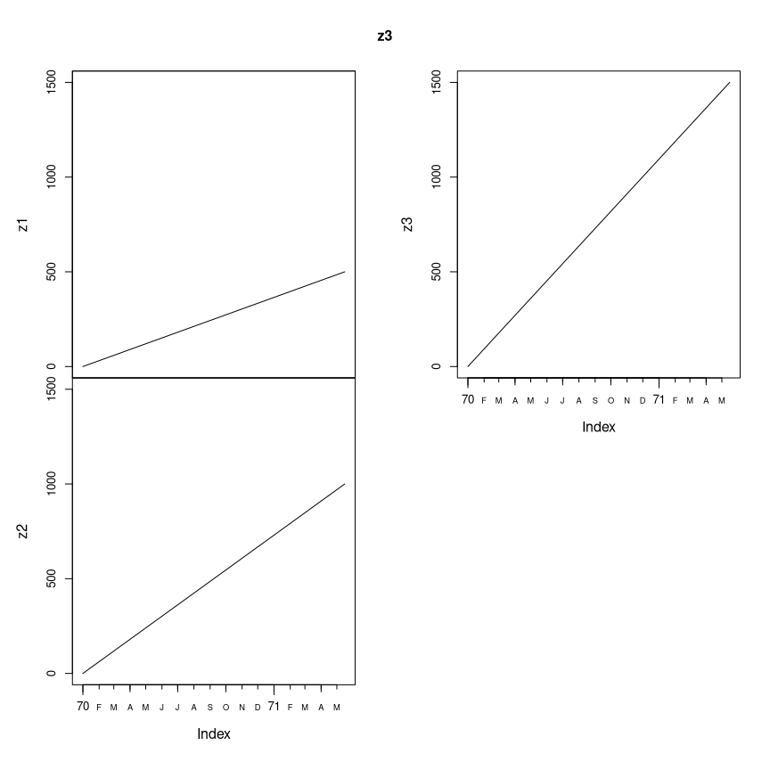

```r
plot(z3, screen = 1:3, xaxt = "n", nc = 2, ylim = range(z3),
  panel = function(...) {
    lines(...)
    panel.number <- parent.frame()$panel.number
    nser <- parent.frame()$nser
    # place axis on bottom panel of each column only
    if (panel.number %% 2 == 0 || panel.number == nser) {
      tt <- list(...)[[1]]
      m <- unique(as.Date(as.yearmon(tt)))
      jan <- format(m, "%m") == "01"
      mlab <- substr(months(m[!jan]), 1, 1)
      axis(side = 1, at = m[!jan], labels = mlab, tcl = -0.3, cex.axis = 0.7)
      axis(side = 1, at = m[jan], labels = format(m[jan], "%y"), tcl = -0.7)
      axis(side = 1, at = unique(as.Date(as.yearqtr(tt))), labels = FALSE)
    }
})
```

## 9. Why is nothing plotted except axes when I plot an object with many `NA`s?

Isolated points surrounded by `NA` values do not form lines:

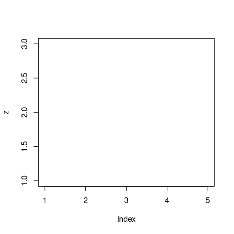

```r
z <- zoo(c(1, NA, 2, NA, 3))
plot(z)
```

So try one of the following:

Plot points rather than lines.

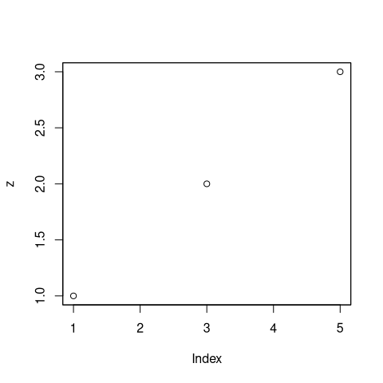

```r
plot(z, type = "p")
```

Omit `NA`s and plot that.

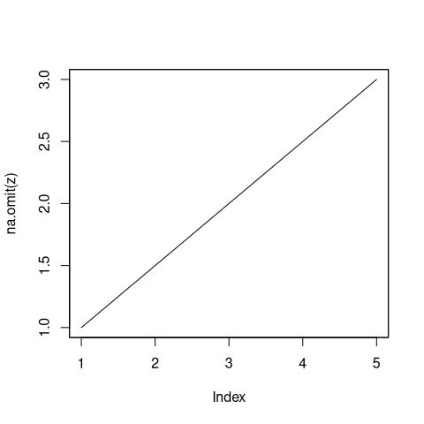

```r
plot(na.omit(z))
```

Fill in the `NA`s with interpolated values.

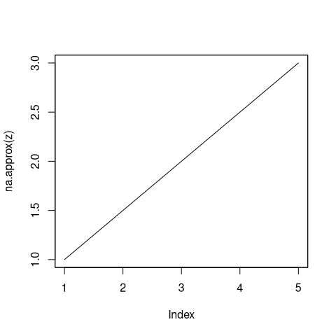

```r
plot(na.approx(z))
```

Plot points with lines superimposed.

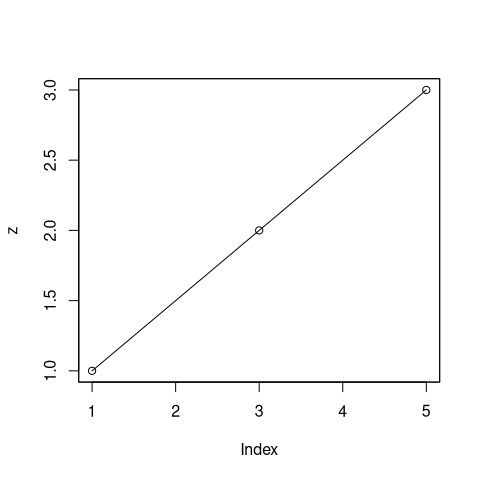

```r
plot(z, type = "p")
lines(na.omit(z))
```

Note that this is not specific to `zoo`. If we plot in R without `zoo` we get the same behavior.

## 10. Does `zoo` work with Rmetrics?

Yes. `timeDate` class objects from the `timeDate` package can be used directly as the index of a `zoo` series and `as.timeSeries.zoo` and `as.zoo.timeSeries` can convert back and forth between objects of class `zoo` and class `timeSeries` from the `timeSeries` package.

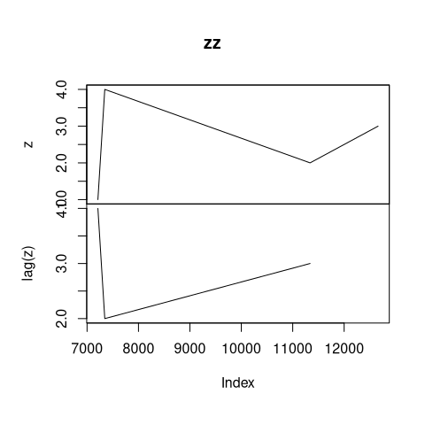

```r
library("timeDate")
dts <- c("1989-09-28", "2001-01-15", "2004-08-30", "1990-02-09")
tms <- c(  "23:12:55",   "10:34:02",   "08:30:00",   "11:18:23")
td <- timeDate(paste(dts, tms), format = "%Y-%m-%d %H:%M:%S")

library("zoo")
z <- zoo(1:4, td)
zz <- merge(z, lag(z))
plot(zz)
```

```r
library("timeSeries")
zz
```

```
##                     z lag(z)
## 1989-09-28 23:12:55 1      4
## 1990-02-09 11:18:23 4      2
## 2001-01-15 10:34:02 2      3
## 2004-08-30 08:30:00 3     NA
```

```r
as.timeSeries(zz)
```

```
## GMT
##                     z lag(z)
## 1989-09-28 23:12:55 1      4
## 1990-02-09 11:18:23 4      2
## 2001-01-15 10:34:02 2      3
## 2004-08-30 08:30:00 3     NA
```

```r
as.zoo(as.timeSeries(zz))
```

```
##                     z lag(z)
## 1989-09-28 23:12:55 1      4
## 1990-02-09 11:18:23 4      2
## 2001-01-15 10:34:02 2      3
## 2004-08-30 08:30:00 3     NA
```